# Tenary Plot

Mirco Brunner

FS 2019

## R Ternary Plots

All data and some Text are from [@baxter_basic_2016] http://www.barbicanra.co.uk/simple-r.html.

Ternary diagrams go under a variety of names ??? triangular, tripolar or phase diagrams among them. They are used when p = 3 variables are available that are scaled to sum to 100% (or 1). The data may be categorical or continuous. This scaling (or compositional constraint) means the values of any two variables determine the value of the third variable. This implies that the data are exactly two-dimensional.The data can be plotted in an equilateral triangle where a point represents the relative proportions of the three variables as measured by the (perpendicular) distances to the three axes. In effect, and as previously noted, a point in a ternary diagram encapsulates the same information as a pie chart for three categories, with the considerable advantage that the distances between points are visualized. Howarth???s (1996) history of the ternary diagram traces its origins to the mid-18th century. Their use in archaeology is widespread, often occurring in the more *specialised* literature. Howarth (1996: 338) notes that they are widely used ingeology, physical chemistry and metallurgy and are to be found in archaeological publications that interact with these disciplines. Recent papers in this vein that use ternary diagrams include Hughes et al. (2010) study of flint compositions, Panich (2016) of obsidian, and Chirikure et al. (2010) of slags. For data sets with more than 3 variables composite variables (i.e. linear combinations of those available) are sometimes defined to enable their representation in a ternary diagram (e.g., Hein et al. 2007: 149; Plaza and Martin??n-Torres 2015: 93). Another use is in phase diagrams where a plot is ???zoned??? in some way to identify, for example, different classes of material or manufacturing technologies corresponding to different regions of the diagram. Data are then plotted to characterize the cases beings studied (e.g., Thornton and Rehren 2009; Radivojevic et al. 2010).

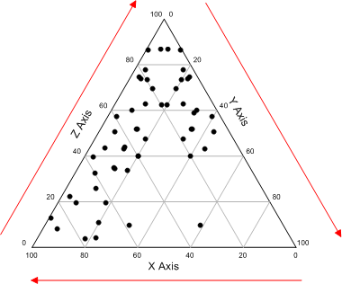

fig. 1: At the end we create this kind of diagrams

```r
#load libraries
library(ggplot2);library(grid); library(ggtern)
#show data
Ksar <- read.csv("data_ksar_akil/ksar_akil.csv")
print(Ksar)
```

```
##    Levels Cores Blanks Tools
## 1      25    21     12    70
## 2      24    36     52   115
## 3      23   126    650   549
## 4      22   159   2342  1633
## 5      21    75    487   511
## 6      20   176   1090   912
## 7      19   132    713   578
## 8      18    46    374   266
## 9      17   550   6182  1541
## 10     16    76    846   349
## 11     15    17    182    51
## 12     14     4     21    14
## 13     13    29    228   130
## 14     12   133   2227   729
```

Table 1: To the left, counts of cores, blanks and tools from middle levels of the palaeolithic site at Ksar Akil (Lebanon). This is Table 9.12 from Doran and Hodson (1975).

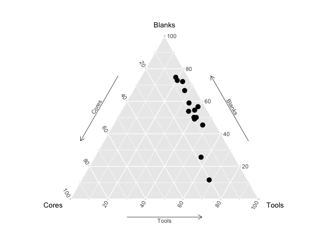

```r
#ternary diagram  with dots fig. 1a
ggtern(data=Ksar[,1:4],aes(Cores, Blanks, Tools, label=Levels)) +
  geom_point(size = 3) + theme_showarrows()
```

fig. 1a: Ternery diagram 1a

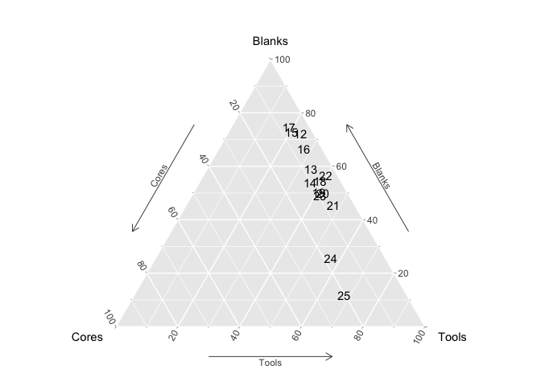

```r
#ternary diagram with numbers fig. 1b
Ksar <- read.csv("data_ksar_akil/ksar_akil.csv")
library(ggplot2);library(grid); library(ggtern)
ggtern(data=Ksar[,1:4],aes(Cores, Blanks, Tools, label=Levels)) +
geom_text() + theme_showarrows()
```

Change the dataset –> data_faunal/king

```r
king <- read.csv("data_faunal/king.csv")
#show data
print(king)
```

```
##            Type    C    P   SG
## 1   Settlement  37.0 10.4 52.6
## 2        Vicus  37.4 13.7 48.9
## 3   Settlement  74.4  4.7 20.9
## 4   Settlement  62.0 10.8 27.2
## 5        Villa  48.7 29.2 22.0
## 6        Villa  56.2 12.9 30.9
## 7        Villa  59.5 10.1 30.4
## 8        Villa  71.3  8.5 20.2
## 9   Settlement  27.0  7.8 65.1
## 10       Vicus  87.3  2.4 10.2
## 11       Vicus  53.0 32.1 15.0
## 12       Villa  60.4 14.2 25.5
## 13       Vicus  76.3  2.5 21.2
## 14       Vicus  74.3  8.9 16.8
```

[output cut: 240 more lines]

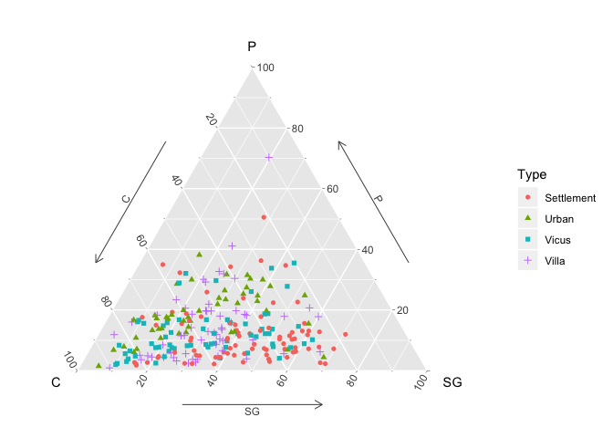

```r
king <- read.csv("data_faunal/king.csv")
ggtern(data=king,aes(C, P, SG, colour=Type, shape=Type, fill = Type)) +
geom_point() + theme_showarrows()
```

The upper plot is the ???default??? ternary diagram for Romano-British civilian faunal assemblages using ggtern; the lower plot is a ???modified??? version. C = Cattle, P = Pig, SG = Sheep/Goat.

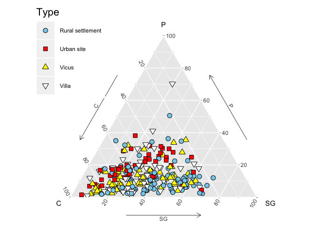

```r
fig2 <- function() {
library(ggplot2); library(grid); library(grid); library(ggtern)
king$Type <- factor(king$Type, labels = c("Rural settlement", "Urban site", "Vicus", "Villa"))
p <- ggtern(data=king,aes(C, P, SG, colour=Type, shape=Type, fill=Type)) +
geom_point(size = 3) + theme_showarrows() +
scale_shape_manual(values=c(21,22,24,25)) +
scale_colour_manual(values=rep("black", 4)) +
scale_fill_manual(values=c("skyblue", "red", "yellow", "white")) +
theme_legend_position("tl") +
theme(legend.title=element_text(size=16),
legend.key.height=unit(1, "cm"), legend.key.width=unit(1, "cm"))
p
}
fig2 ()
```

If your happy with the plot save it!

```r
ggsave("fig2.png", dpi = 300)
```